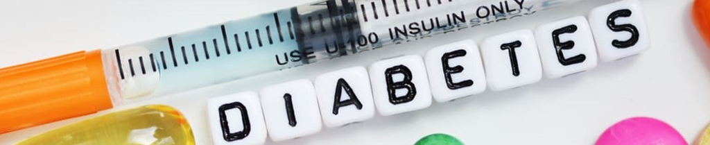

# Diabetes Project

```python
import pandas as pd
import numpy as np
import seaborn as sns
import matplotlib.pyplot as plt
```

```python
dataset = pd.read_csv('Diabetes.csv')
```

```python
dataset
```

|  | Pregnancies | Glucose | BloodPressure | SkinThickness | Insulin | BMI | DiabetesPedigreeFunction | Age | Outcome |
| --- | --- | --- | --- | --- | --- | --- | --- | --- | --- |
| 0 | 6 | 148 | 72 | 35 | 0 | 33.6 | 0.627 | 50 | 1 |
| 1 | 1 | 85 | 66 | 29 | 0 | 26.6 | 0.351 | 31 | 0 |
| 2 | 8 | 183 | 64 | 0 | 0 | 23.3 | 0.672 | 32 | 1 |
| 3 | 1 | 89 | 66 | 23 | 94 | 28.1 | 0.167 | 21 | 0 |
| 4 | 0 | 137 | 40 | 35 | 168 | 43.1 | 2.288 | 33 | 1 |
| ... | ... | ... | ... | ... | ... | ... | ... | ... | ... |
| 763 | 10 | 101 | 76 | 48 | 180 | 32.9 | 0.171 | 63 | 0 |
| 764 | 2 | 122 | 70 | 27 | 0 | 36.8 | 0.340 | 27 | 0 |
| 765 | 5 | 121 | 72 | 23 | 112 | 26.2 | 0.245 | 30 | 0 |
| 766 | 1 | 126 | 60 | 0 | 0 | 30.1 | 0.349 | 47 | 1 |
| 767 | 1 | 93 | 70 | 31 | 0 | 30.4 | 0.315 | 23 | 0 |

768 rows × 9 columns

```
No. of Diabetic Patient in dataset: 268
No. of NON Diabetic Patient in dataset: 500
```

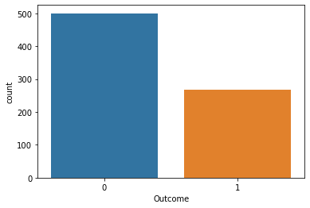

```python
print('No. of Diabetic Patient in dataset: %d\nNo. of NON Diabetic Patient in dataset: %d'%(len(dataset[dataset.Outcome ==1]),len(dataset[dataset.Outcome ==0])))
sns.countplot(dataset.Outcome)
```

```python
from sklearn.model_selection import train_test_split
dataset0 = dataset[dataset.Outcome == 0]
data_0x, rem_0x,data_0y, rem_0y = train_test_split(dataset0.drop('Outcome', axis =1), dataset0.Outcome,train_size = len(dataset[dataset.Outcome == 1]),random_state = 42)
```

```python
data0 = pd.concat([data_0x,data_0y], axis=1)
data1 = dataset[dataset.Outcome == 1]
data = pd.concat([data0,data1], axis = 0)
data.sort_index(inplace = True)
data
```

|  | Pregnancies | Glucose | BloodPressure | SkinThickness | Insulin | BMI | DiabetesPedigreeFunction | Age | Outcome |
| --- | --- | --- | --- | --- | --- | --- | --- | --- | --- |
| 0 | 6 | 148 | 72 | 35 | 0 | 33.6 | 0.627 | 50 | 1 |
| 2 | 8 | 183 | 64 | 0 | 0 | 23.3 | 0.672 | 32 | 1 |
| 3 | 1 | 89 | 66 | 23 | 94 | 28.1 | 0.167 | 21 | 0 |
| 4 | 0 | 137 | 40 | 35 | 168 | 43.1 | 2.288 | 33 | 1 |
| 6 | 3 | 78 | 50 | 32 | 88 | 31.0 | 0.248 | 26 | 1 |
| ... | ... | ... | ... | ... | ... | ... | ... | ... | ... |
| 761 | 9 | 170 | 74 | 31 | 0 | 44.0 | 0.403 | 43 | 1 |
| 763 | 10 | 101 | 76 | 48 | 180 | 32.9 | 0.171 | 63 | 0 |
| 765 | 5 | 121 | 72 | 23 | 112 | 26.2 | 0.245 | 30 | 0 |
| 766 | 1 | 126 | 60 | 0 | 0 | 30.1 | 0.349 | 47 | 1 |
| 767 | 1 | 93 | 70 | 31 | 0 | 30.4 | 0.315 | 23 | 0 |

536 rows × 9 columns

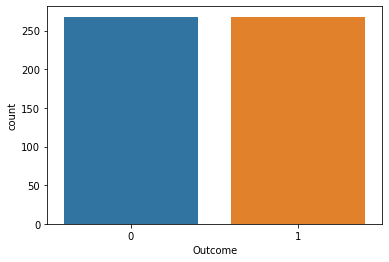

```python
sns.countplot(data.Outcome)
```

```python
data.info()
```

```
<class 'pandas.core.frame.DataFrame'>
Int64Index: 536 entries, 0 to 767
Data columns (total 9 columns):
 #   Column                    Non-Null Count  Dtype
---  ------                    --------------  -----
 0   Pregnancies               536 non-null    int64
 1   Glucose                   536 non-null    int64
 2   BloodPressure             536 non-null    int64
 3   SkinThickness             536 non-null    int64
 4   Insulin                   536 non-null    int64
 5   BMI                       536 non-null    float64
 6   DiabetesPedigreeFunction  536 non-null    float64
 7   Age                       536 non-null    int64
 8   Outcome                   536 non-null    int64
dtypes: float64(2), int64(7)
memory usage: 61.9 KB
```

```python
data.describe().T
```

|  | count | mean | std | min | 25% | 50% | 75% | max |
| --- | --- | --- | --- | --- | --- | --- | --- | --- |
| Pregnancies | 536.0 | 4.057836 | 3.544960 | 0.000 | 1.00000 | 3.0000 | 7.00000 | 17.00 |
| Glucose | 536.0 | 126.384328 | 32.702477 | 0.000 | 102.00000 | 124.0000 | 147.00000 | 199.00 |
| BloodPressure | 536.0 | 69.680970 | 20.033544 | 0.000 | 64.00000 | 72.0000 | 80.00000 | 114.00 |
| SkinThickness | 536.0 | 21.611940 | 16.394282 | 0.000 | 0.00000 | 24.0000 | 34.00000 | 99.00 |
| Insulin | 536.0 | 89.097015 | 124.555186 | 0.000 | 0.00000 | 40.5000 | 142.50000 | 846.00 |
| BMI | 536.0 | 32.851679 | 7.886216 | 0.000 | 27.60000 | 32.8000 | 37.52500 | 67.10 |
| DiabetesPedigreeFunction | 536.0 | 0.479140 | 0.328765 | 0.078 | 0.24475 | 0.3805 | 0.64625 | 2.42 |
| Age | 536.0 | 34.164179 | 11.987186 | 21.000 | 24.00000 | 30.0000 | 42.00000 | 81.00 |
| Outcome | 536.0 | 0.500000 | 0.500467 | 0.000 | 0.00000 | 0.5000 | 1.00000 | 1.00 |

- As we can observe, there's no missing values in the data.
- We can move forward to the next step and start dealing with zeroes in various columns like Blood Pressure, Skin Thickness etc.

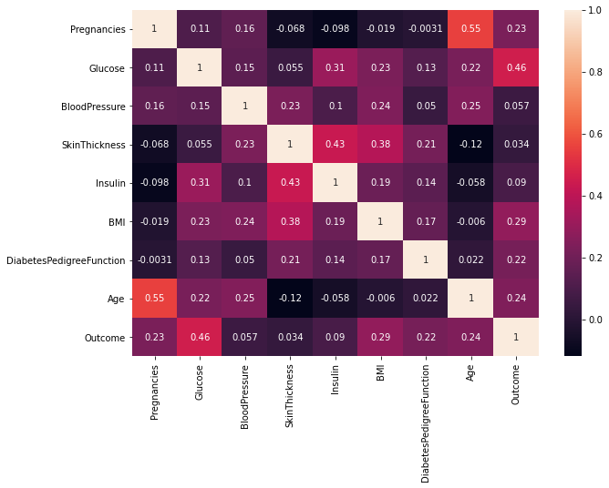

```python
# The heatmap gives us the visual representation of correlation between variables.
plt.figure(figsize = (10,7))
sns.heatmap(data.corr(),annot= True);
```

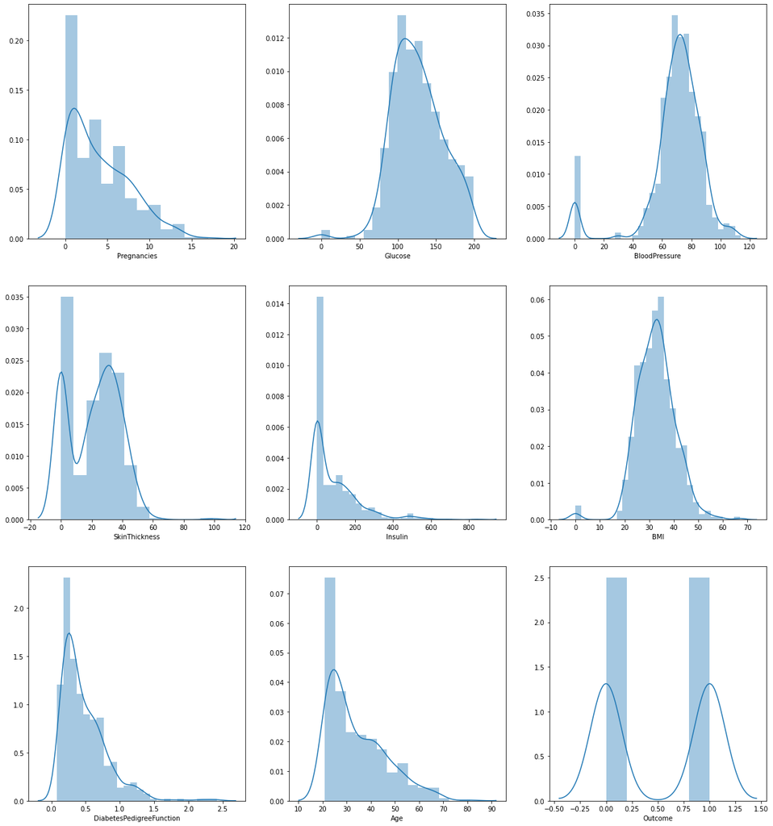

```python
plt.figure(figsize=(20,30))
plotnumber = 1
for i in data:
    plt.subplot(4,3,plotnumber)
    sns.distplot(data[str(i)])
    plotnumber += 1
```

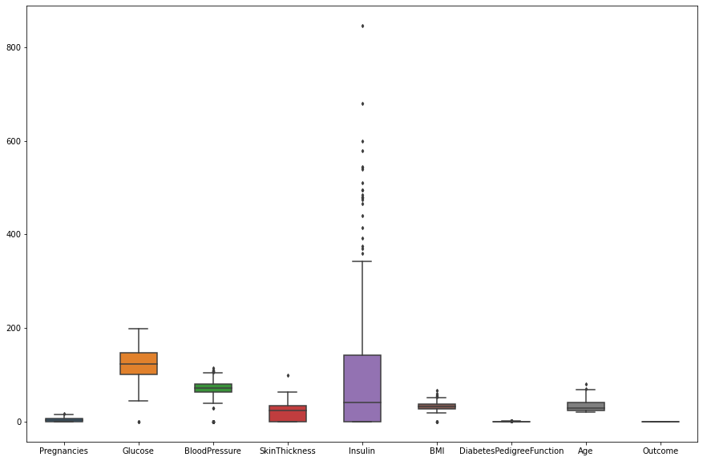

```python
fig, ax = plt.subplots(figsize = (15,10))
sns.boxplot(data = data, width = 0.5,ax = ax, fliersize= 3)
```

```python
for i in data.columns:
    print('In ', i,', mean is ', data[data[i] !=0][i].mean(),' and median is ', data[data[i] != 0][i].median())
```

```
In  Pregnancies , mean is  4.844097995545657  and median is  4.0
In  Glucose , mean is  127.09568480300187  and median is  124.0
In  BloodPressure , mean is  73.37721021611002  and median is  74.0
In  SkinThickness , mean is  30.32460732984293  and median is  30.5
In  Insulin , mean is  171.7841726618705  and median is  140.0
In  BMI , mean is  33.161016949152526  and median is  32.8
In  DiabetesPedigreeFunction , mean is  0.4791399253731345  and median is  0.3805
In  Age , mean is  34.16417910447761  and median is  30.0
In  Outcome , mean is  1.0  and median is  1.0
```

```python
for i in data.columns:
    print(i)
```

```
Pregnancies
Glucose
BloodPressure
SkinThickness
Insulin
BMI
DiabetesPedigreeFunction
Age
Outcome
```

```python
data.Glucose.replace(0, data.Glucose.mean(), inplace= True)
data.BloodPressure.replace(0, data.BloodPressure.median(), inplace= True)
data.SkinThickness.replace(0, data.SkinThickness.median(), inplace= True)
data.Insulin.replace(0, data.Insulin.mean(), inplace= True)
data.BMI.replace(0, data.BMI.median(), inplace= True)
```

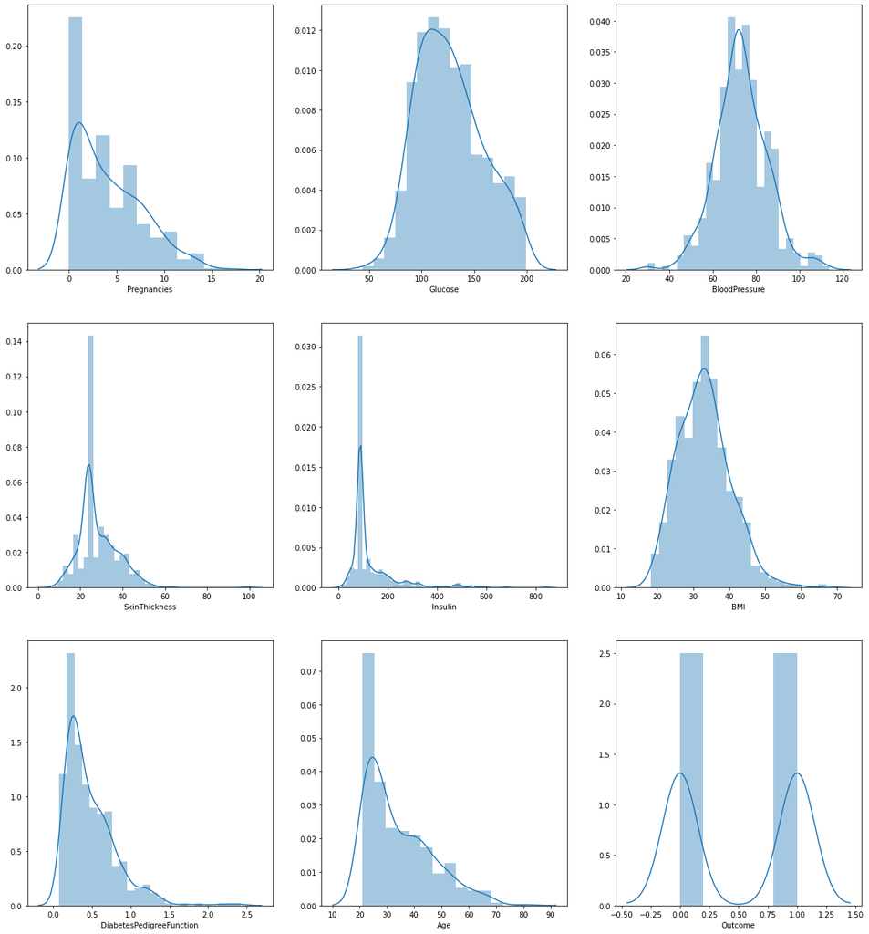

```python
plt.figure(figsize=(20,30))
plotnumber = 1
for i in data:
    plt.subplot(4,3,plotnumber)
    sns.distplot(data[str(i)])
    plotnumber += 1
```

```python
from plotly.offline import iplot
import plotly as py
import plotly.tools as tls
py.offline.init_notebook_mode(connected=True)
import cufflinks as cf
```

```python
import cufflinks as cf
cf.go_offline()
import plotly.figure_factory as ff
```

```python
for i in data.columns:
    fig = ff.create_distplot([data[i]], group_labels= [str(i)], show_rug= False)
    fig.show()
```

[interactive chart not shown]

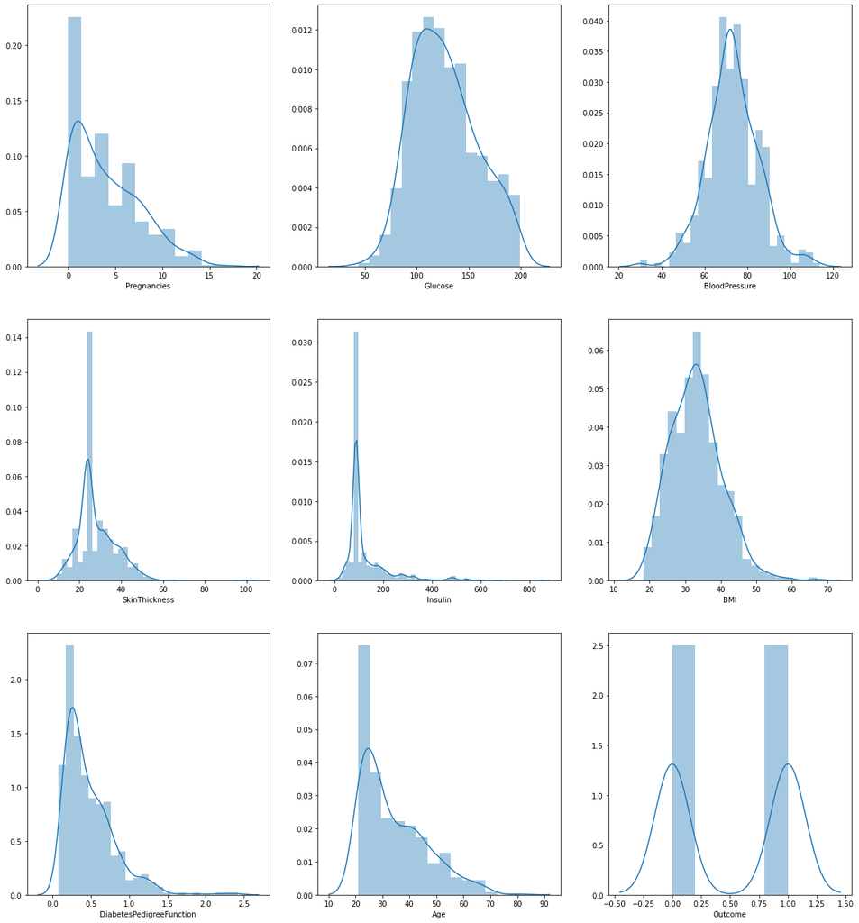

```python
plt.figure(figsize=(20,30))
plotnumber = 1
for i in data:
    plt.subplot(4,3,plotnumber)
    sns.distplot(data[str(i)])
    plotnumber += 1
```

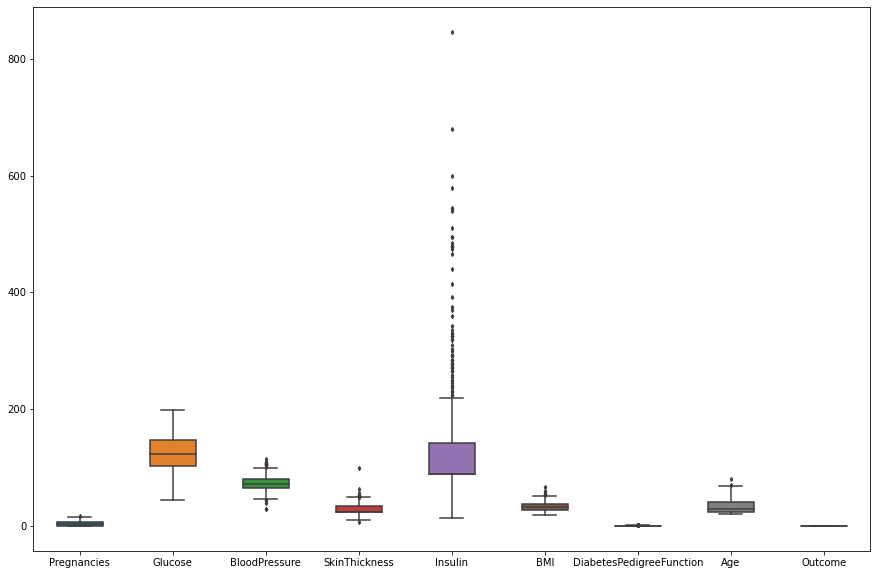

```python
fig, ax = plt.subplots(figsize = (15,10))
sns.boxplot(data = data, width = 0.5,ax = ax, fliersize= 3)
```

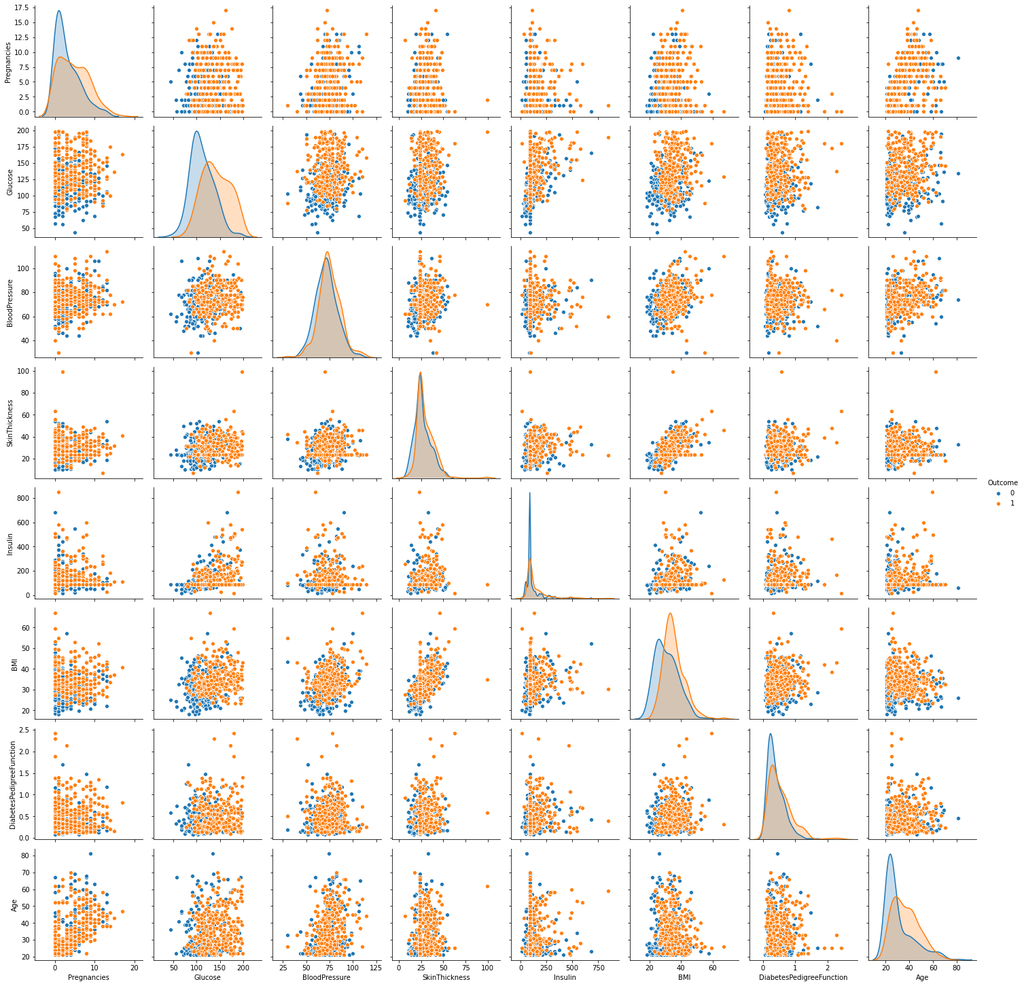

```python
sns.pairplot(data,hue = 'Outcome')
```

# Outlier

- Dataset already have very few rows, so we can't drop the rows containing outliers.
- So, we replace the value of outliers with mean + 3*sigma value in case of symmetric distribution or with median + 3*IQR in case of highly skewed distribution .

```python
# Maximum Blood Pressure is 114, This can't be considered as an outlier. So, we leave them as it is.
ra = data.BloodPressure.mean() + 3 * data.BloodPressure.std()
ra = data.BloodPressure.mean() + 3 * data.BloodPressure.std()
data[data.BloodPressure > ra]
```

|  | Pregnancies | Glucose | BloodPressure | SkinThickness | Insulin | BMI | DiabetesPedigreeFunction | Age | Outcome |
| --- | --- | --- | --- | --- | --- | --- | --- | --- | --- |
| 43 | 9 | 171.0 | 110 | 24 | 240.000000 | 45.4 | 0.721 | 54 | 1 |
| 177 | 0 | 129.0 | 110 | 46 | 130.000000 | 67.1 | 0.319 | 26 | 1 |
| 691 | 13 | 158.0 | 114 | 24 | 89.097015 | 42.3 | 0.257 | 44 | 1 |

```python
# Blood Pressure of 30 is not feasible and can be considered as an outlier.
rb = data.BloodPressure.mean() - 3 * data.BloodPressure.std()
data[data.BloodPressure < rb]
```

|  | Pregnancies | Glucose | BloodPressure | SkinThickness | Insulin | BMI | DiabetesPedigreeFunction | Age | Outcome |
| --- | --- | --- | --- | --- | --- | --- | --- | --- | --- |
| 18 | 1 | 103.0 | 30 | 38 | 83.0 | 43.3 | 0.183 | 33 | 0 |
| 125 | 1 | 88.0 | 30 | 42 | 99.0 | 55.0 | 0.496 | 26 | 1 |

```python
data.BloodPressure.replace(list(data.BloodPressure[data.BloodPressure < rb]),rb,inplace = True)
```

```python
#Skin THickness
r = data.SkinThickness.median() + 3 * (data.SkinThickness.quantile(0.75) - data.SkinThickness.quantile(0.25))
data[data.SkinThickness > r]
```

|  | Pregnancies | Glucose | BloodPressure | SkinThickness | Insulin | BMI | DiabetesPedigreeFunction | Age | Outcome |
| --- | --- | --- | --- | --- | --- | --- | --- | --- | --- |
| 120 | 0 | 162.0 | 76.0 | 56 | 100.000000 | 53.2 | 0.759 | 25 | 1 |
| 445 | 0 | 180.0 | 78.0 | 63 | 14.000000 | 59.4 | 2.420 | 25 | 1 |
| 579 | 2 | 197.0 | 70.0 | 99 | 89.097015 | 34.7 | 0.575 | 62 | 1 |

```python
data.SkinThickness.replace(list(data.SkinThickness[data.SkinThickness > r]),r,inplace = True)
```

```python
# Insulin
r = data.Insulin.median() + 8 * (data.Insulin.quantile(0.75) - data.Insulin.quantile(0.25))
data[data.Insulin > r]
```

|  | Pregnancies | Glucose | BloodPressure | SkinThickness | Insulin | BMI | DiabetesPedigreeFunction | Age | Outcome |
| --- | --- | --- | --- | --- | --- | --- | --- | --- | --- |
| 8 | 2 | 197.0 | 70.0 | 45 | 543.0 | 30.5 | 0.158 | 53 | 1 |
| 13 | 1 | 189.0 | 60.0 | 23 | 846.0 | 30.1 | 0.398 | 59 | 1 |
| 247 | 0 | 165.0 | 90.0 | 33 | 680.0 | 52.3 | 0.427 | 23 | 0 |
| 286 | 5 | 155.0 | 84.0 | 44 | 545.0 | 38.7 | 0.619 | 34 | 0 |
| 409 | 1 | 172.0 | 68.0 | 49 | 579.0 | 42.4 | 0.702 | 28 | 1 |
| 584 | 8 | 124.0 | 76.0 | 24 | 600.0 | 28.7 | 0.687 | 52 | 1 |
| 655 | 2 | 155.0 | 52.0 | 27 | 540.0 | 38.7 | 0.240 | 25 | 1 |

```python
r
```

```
516.3208955223881
```

```python
data.Insulin.replace(list(data.Insulin[data.Insulin > r]),r,inplace = True)
```

```python
# BMI
r = data.BMI.mean() + 3 * data.BMI.std()
data[data.BMI > r]
```

|  | Pregnancies | Glucose | BloodPressure | SkinThickness | Insulin | BMI | DiabetesPedigreeFunction | Age | Outcome |
| --- | --- | --- | --- | --- | --- | --- | --- | --- | --- |
| 125 | 1 | 88.0 | 37.383568 | 42 | 99.0 | 55.0 | 0.496 | 26 | 1 |
| 177 | 0 | 129.0 | 110.000000 | 46 | 130.0 | 67.1 | 0.319 | 26 | 1 |
| 445 | 0 | 180.0 | 78.000000 | 54 | 14.0 | 59.4 | 2.420 | 25 | 1 |
| 673 | 3 | 123.0 | 100.000000 | 35 | 240.0 | 57.3 | 0.880 | 22 | 0 |

```python
# These high values of BMI is not possible, so we replace them.
data.BMI.replace(list(data.BMI[data.BMI > r]),r,inplace = True)
```

```python
# Age
data[data.Age == data.Age.max()]
#This cannot be an outlier
```

|  | Pregnancies | Glucose | BloodPressure | SkinThickness | Insulin | BMI | DiabetesPedigreeFunction | Age | Outcome |
| --- | --- | --- | --- | --- | --- | --- | --- | --- | --- |
| 459 | 9 | 134.0 | 74.0 | 33 | 60.0 | 25.9 | 0.46 | 81 | 0 |

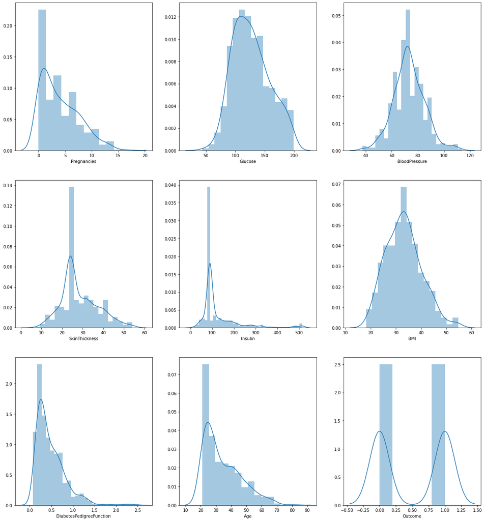

```python
plt.figure(figsize=(20,30))
plotnumber = 1
for i in data:
    plt.subplot(4,3,plotnumber)
    sns.distplot(data[str(i)])
    plotnumber += 1
```

```python
data
```

|  | Pregnancies | Glucose | BloodPressure | SkinThickness | Insulin | BMI | DiabetesPedigreeFunction | Age | Outcome |
| --- | --- | --- | --- | --- | --- | --- | --- | --- | --- |
| 0 | 6 | 148.0 | 72.0 | 35 | 89.097015 | 33.6 | 0.627 | 50 | 1 |
| 2 | 8 | 183.0 | 64.0 | 24 | 89.097015 | 23.3 | 0.672 | 32 | 1 |
| 3 | 1 | 89.0 | 66.0 | 23 | 94.000000 | 28.1 | 0.167 | 21 | 0 |
| 4 | 0 | 137.0 | 40.0 | 35 | 168.000000 | 43.1 | 2.288 | 33 | 1 |
| 6 | 3 | 78.0 | 50.0 | 32 | 88.000000 | 31.0 | 0.248 | 26 | 1 |
| ... | ... | ... | ... | ... | ... | ... | ... | ... | ... |
| 761 | 9 | 170.0 | 74.0 | 31 | 89.097015 | 44.0 | 0.403 | 43 | 1 |
| 763 | 10 | 101.0 | 76.0 | 48 | 180.000000 | 32.9 | 0.171 | 63 | 0 |
| 765 | 5 | 121.0 | 72.0 | 23 | 112.000000 | 26.2 | 0.245 | 30 | 0 |
| 766 | 1 | 126.0 | 60.0 | 24 | 89.097015 | 30.1 | 0.349 | 47 | 1 |
| 767 | 1 | 93.0 | 70.0 | 31 | 89.097015 | 30.4 | 0.315 | 23 | 0 |

536 rows × 9 columns

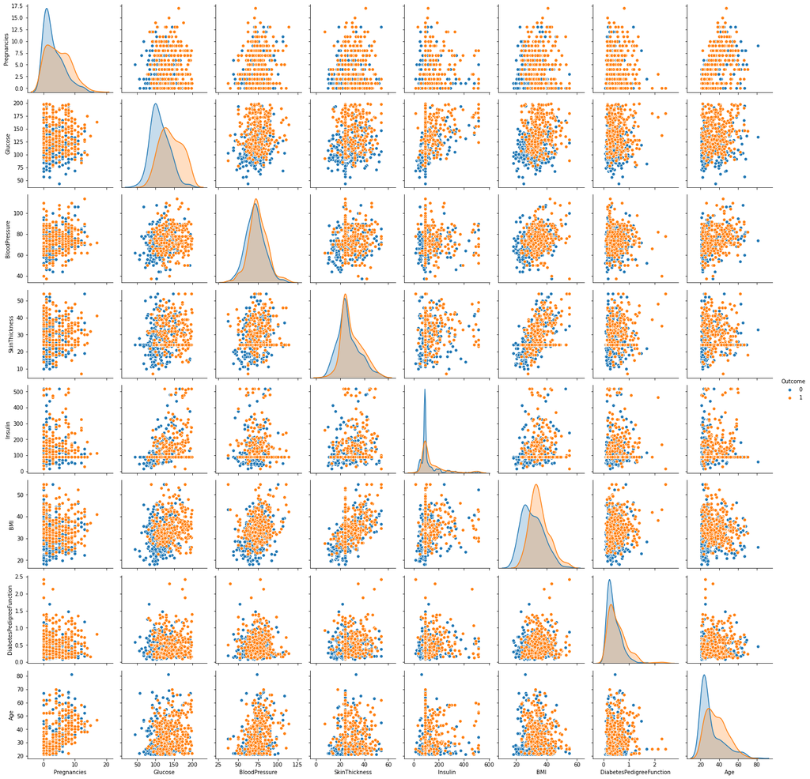

```python
sns.pairplot(data,hue = 'Outcome')
```

```python
X = data.drop(['Outcome'], axis = 1)
Y = data.Outcome
```

```python
categorical = [i for i in data.columns if len(data[str(i)].unique()) < 20 and i != 'Outcome']
numerical = [i for i in data.columns if i not in categorical and i !='Outcome']
```

```python
import scipy.stats as stats
for i in numerical:
    print(i,': ',stats.f_oneway(X[i][Y == 0],X[i][Y == 1]))
```

```
Glucose :  F_onewayResult(statistic=162.6922383089287, pvalue=1.0298148232095181e-32)
BloodPressure :  F_onewayResult(statistic=12.78399337864147, pvalue=0.0003813213975364279)
SkinThickness :  F_onewayResult(statistic=14.268053073099452, pvalue=0.0001763540747299242)
Insulin :  F_onewayResult(statistic=11.870360036249817, pvalue=0.0006152102823416904)
BMI :  F_onewayResult(statistic=57.37518020124728, pvalue=1.597222217358356e-13)
DiabetesPedigreeFunction :  F_onewayResult(statistic=26.453920798652668, pvalue=3.7957865779801543e-07)
Age :  F_onewayResult(statistic=33.335429309285026, pvalue=1.3169291842758495e-08)
```

```python
from scipy import stats
print("H0 : Assume there is no dependence between two variable")
print("H1 : Assume there is dependence between two variable")
var1 = []
var2 = []
chi2 = []
df = []
p = []
d = []
h = []
for i in categorical:
            cross_tab = pd.crosstab(X[str(i)],Y)
            chi2_stat, p_val, dof, ex = stats.chi2_contingency(cross_tab)
            var1.append(i)
            var2.append('Outcome')
            chi2.append(chi2_stat)
            df.append(dof)
            p.append(p_val)
            if p_val > 0.05:
                d.append('Independent')
                h.append('Accepted')
            else:
                d.append('Dependent')
                h.append('Rejected')
a = pd.DataFrame([var1,var2,chi2,df,p,d,h],index=['variable 1','variable 2','Chi2 Value','DOF','P Value','Decison (5% LOS)','Null Hypothesis']).T
a
```

```
H0 : Assume there is no dependence between two variable
H1 : Assume there is dependence between two variable
```

|  | variable 1 | variable 2 | Chi2 Value | DOF | P Value | Decison (5% LOS) | Null Hypothesis |
| --- | --- | --- | --- | --- | --- | --- | --- |
| 0 | Pregnancies | Outcome | 45.6038 | 16 | 0.000112084 | Dependent | Rejected |

Since all the variables have pvalue < 0.05, we can conclude that they are significatnt for predicting the Outcome.

```python
from sklearn.model_selection import train_test_split
x_train, x_test, y_train, y_test = train_test_split(X, Y, test_size = 0.20, random_state = 35 )
```

```python
from sklearn.preprocessing import StandardScaler
scalar = StandardScaler()
x_train = scalar.fit_transform(x_train)
x_test = scalar.transform(x_test)
X_scaled = scalar.fit_transform(X)
```

This Problem is related to Diabetes detection, So our main objective is to build a model that can correctly predict whether a patient is diabetic or not. We should give more priority to `maximize Recall or Sensitivity` and at the same time we should maximize `Precision` or we can say we should minimize the False Positive Rate.

#### Recall or Sensitivity

The mathematical formula is:

**Recall**= $ \frac{ TP}{(TP+FN)} $

Or, as the name suggests, it is a measure of: from the total number of positive results how many positives were correctly predicted by the model.

### Precision

Precision is a measure of amongst all the positive predictions, how many of them were actually positive. Mathematically,

Precision=$ \frac {TP}{(TP+FP)} $

#### AUC(Area Under Curve)

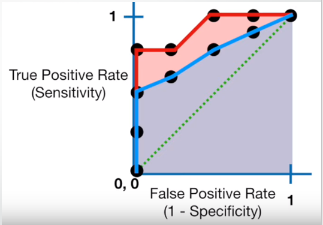

- It helps us to choose the best model amongst the models for which we have plotted the ROC curves
- The best model is the one which encompasses the maximum area under it.
- In the adjacent diagram, amongst the two curves, the model that resulted in the red one should be chosen as it clearly covers more area than the blue one

In order to do comparison among the models, we use AUC (Area under curve) of Receiver Operator Characteristic, The model with Higher AUC would be selected.

```python
from sklearn.metrics import confusion_matrix, roc_auc_score
def score(model, x_test, y_test):
    y_pred = model.predict(x_test)

    conf_mat = confusion_matrix(y_test,y_pred)
    true_positive = conf_mat[1][1]
    false_positive = conf_mat[0][1]
    false_negative = conf_mat[1][0]
    true_negative = conf_mat[0][0]

    Accuracy = (true_positive+true_negative)/(true_positive+true_negative+false_negative+false_positive)
    Precision = true_positive/(true_positive+false_positive)
    Recall = true_positive/(true_positive+false_negative)
    F1_Score = 2*(Recall * Precision) / (Recall + Precision)
    auc = roc_auc_score(y_test, y_pred)

    print('Model Name\t',model)
    print('Accuracy\t {:.4f}'.format(Accuracy))
    print('Precision\t {:.4f}'.format(Precision))
    print('Recall\t\t {:.4f}'.format(Recall))
    print('F1 Score\t {:.4f}'.format(F1_Score))
    print('AUC\t\t {:.4f}'.format(auc))
```

```python
# Creating a function for Cross Validation
from numpy import mean
from numpy import std
from sklearn.metrics import recall_score
from sklearn.model_selection import KFold
from sklearn.model_selection import cross_val_score
cv = KFold(n_splits=10, random_state=1, shuffle=True)

def kcross(model,X,Y):
    scores = cross_val_score(model, X, Y, scoring='accuracy', cv=cv, n_jobs=-1)
    print('Accuracy: %.3f (%.3f)' % (mean(scores), std(scores)))
    scores = cross_val_score(model, X, Y, scoring='precision', cv=cv, n_jobs=-1)
    print('Precision: %.3f (%.3f)' % (mean(scores), std(scores)))
    scores = cross_val_score(model, X, Y, scoring='recall', cv=cv, n_jobs=-1)
    print('Recall: %.3f (%.3f)' % (mean(scores), std(scores)))
    scores = cross_val_score(model, X, Y, scoring='f1', cv=cv, n_jobs=-1)
    print('F1 Score: %.3f (%.3f)' % (mean(scores), std(scores)))
    scores = cross_val_score(model, X, Y, scoring='roc_auc', cv=cv, n_jobs=-1)
    print('AUC: %.3f (%.3f)' % (mean(scores), std(scores)))
```

# Logistic Regression

```python
from sklearn.linear_model  import LogisticRegression
# create model
model = LogisticRegression()
model.fit(x_train,y_train);
```

```python
score(model,x_test,y_test)
```

```
Model Name	 LogisticRegression()
Accuracy	 0.7778
Precision	 0.8261
Recall		 0.7037
F1 Score	 0.7600
AUC		 0.7778
```

```python
kcross(model,X_scaled,Y)
```

```
Accuracy: 0.733 (0.068)
Precision: 0.734 (0.099)
Recall: 0.725 (0.093)
F1 Score: 0.725 (0.079)
AUC: 0.834 (0.067)
```

```python
from scipy.stats import uniform
parameter = {'C' : uniform(loc = 0,scale =4) ,'penalty' : ['l1','l2','elasticnet']}
from sklearn.model_selection import RandomizedSearchCV
rand_search = RandomizedSearchCV(estimator=model,param_distributions=parameter,cv =5,scoring='roc_auc'  ,verbose =1, n_jobs=-1,n_iter=10000)
rand_search.fit(x_train,y_train)
model = LogisticRegression(C = rand_search.best_params_['C'],penalty = rand_search.best_params_['penalty'] ,solver = 'liblinear')
model.fit(x_train,y_train)
```

```
Fitting 5 folds for each of 10000 candidates, totalling 50000 fits
```

```
[Parallel(n_jobs=-1)]: Using backend LokyBackend with 8 concurrent workers.
[Parallel(n_jobs=-1)]: Done  56 tasks      | elapsed:    0.0s
[Parallel(n_jobs=-1)]: Done 6640 tasks      | elapsed:    4.5s
[Parallel(n_jobs=-1)]: Done 22640 tasks      | elapsed:   15.2s
[Parallel(n_jobs=-1)]: Done 45040 tasks      | elapsed:   31.2s
[Parallel(n_jobs=-1)]: Done 50000 out of 50000 | elapsed:   34.7s finished
```

```
LogisticRegression(C=0.2548576057947547, solver='liblinear')
```

```python
score(model,x_test,y_test)
```

```
Model Name	 LogisticRegression(C=0.2548576057947547, solver='liblinear')
Accuracy	 0.7870
Precision	 0.8298
Recall		 0.7222
F1 Score	 0.7723
AUC		 0.7870
```

```python
kcross(model,X_scaled,Y)
```

```
Accuracy: 0.735 (0.068)
Precision: 0.737 (0.100)
Recall: 0.725 (0.093)
F1 Score: 0.726 (0.079)
AUC: 0.833 (0.069)
```

# Decision Tree

```python
from sklearn.tree import DecisionTreeClassifier
# create model
model = DecisionTreeClassifier()
model.fit(x_train,y_train)
score(model,x_test,y_test)
```

```
Model Name	 DecisionTreeClassifier()
Accuracy	 0.7500
Precision	 0.7647
Recall		 0.7222
F1 Score	 0.7429
AUC		 0.7500
```

```python
kcross(model,X_scaled,Y)
```

```
Accuracy: 0.728 (0.043)
Precision: 0.729 (0.091)
Recall: 0.708 (0.072)
F1 Score: 0.708 (0.078)
AUC: 0.707 (0.046)
```

```python
parameter = {
    'criterion': ['gini', 'entropy'],
    'max_depth' : range(2,32,1),
    'min_samples_leaf' : range(1,10,1),
    'min_samples_split': range(2,10,1),
    'splitter' : ['best', 'random'],

}
from sklearn.model_selection import RandomizedSearchCV
rand_search = RandomizedSearchCV(estimator=model,param_distributions=parameter,scoring='roc_auc',cv =5, verbose =1, n_jobs=-1,n_iter=10000)
rand_search.fit(x_train,y_train)
model = DecisionTreeClassifier(criterion = rand_search.best_params_['criterion'],max_depth = rand_search.best_params_['max_depth'],min_samples_leaf = rand_search.best_params_['min_samples_leaf'],min_samples_split = rand_search.best_params_['min_samples_split'],splitter = rand_search.best_params_['splitter'])
model.fit(x_train,y_train)
```

```
Fitting 5 folds for each of 8640 candidates, totalling 43200 fits
```

```
[Parallel(n_jobs=-1)]: Done  56 tasks      | elapsed:    0.0s
[Parallel(n_jobs=-1)]: Done 6640 tasks      | elapsed:    5.2s
[Parallel(n_jobs=-1)]: Done 22640 tasks      | elapsed:   18.0s
[Parallel(n_jobs=-1)]: Done 42808 tasks      | elapsed:   34.9s
[Parallel(n_jobs=-1)]: Done 43200 out of 43200 | elapsed:   35.1s finished
```

```
DecisionTreeClassifier(criterion='entropy', max_depth=10, min_samples_leaf=8,
                       min_samples_split=3, splitter='random')
```

```python
score(model,x_test,y_test)
```

```
Model Name	 DecisionTreeClassifier(criterion='entropy', max_depth=10, min_samples_leaf=8,
                       min_samples_split=3, splitter='random')
Accuracy	 0.7222
Precision	 0.8000
Recall		 0.5926
F1 Score	 0.6809
AUC		 0.7222
```

```python
kcross(model,X_scaled,Y)
```

```
Accuracy: 0.701 (0.054)
Precision: 0.744 (0.083)
Recall: 0.722 (0.072)
F1 Score: 0.706 (0.058)
AUC: 0.789 (0.053)
```

# Random Forest

```python
from sklearn.ensemble import RandomForestClassifier
# create model
model = RandomForestClassifier()
model.fit(x_train,y_train)
score(model,x_test,y_test)
```

```
Model Name	 RandomForestClassifier()
Accuracy	 0.7685
Precision	 0.7843
Recall		 0.7407
F1 Score	 0.7619
AUC		 0.7685
```

```python
kcross(model,X_scaled,Y)
```

```
Accuracy: 0.752 (0.073)
Precision: 0.740 (0.084)
Recall: 0.785 (0.093)
F1 Score: 0.758 (0.060)
AUC: 0.824 (0.055)
```

```python
parameter = {
    "n_estimators" : [90,100,115,130],
    'criterion': ['gini', 'entropy'],
    'max_depth' : range(2,20,1),
    'min_samples_leaf' : range(1,10,1),
    'min_samples_split': range(2,10,1),

}
from sklearn.model_selection import RandomizedSearchCV
rand_search = RandomizedSearchCV(estimator=model,param_distributions=parameter,scoring='roc_auc',cv =5, verbose =1, n_jobs=-1,n_iter=500)
rand_search.fit(x_train,y_train)
model = RandomForestClassifier(n_estimators = rand_search.best_params_['n_estimators'],criterion = rand_search.best_params_['criterion'],min_samples_leaf = rand_search.best_params_['min_samples_leaf'],min_samples_split = rand_search.best_params_['min_samples_split'],max_depth = rand_search.best_params_['max_depth'])
model.fit(x_train,y_train)
```

```
Fitting 5 folds for each of 500 candidates, totalling 2500 fits
```

```
[Parallel(n_jobs=-1)]: Using backend LokyBackend with 8 concurrent workers.
[Parallel(n_jobs=-1)]: Done  34 tasks      | elapsed:    2.0s
[Parallel(n_jobs=-1)]: Done 184 tasks      | elapsed:   10.7s
[Parallel(n_jobs=-1)]: Done 434 tasks      | elapsed:   25.9s
[Parallel(n_jobs=-1)]: Done 784 tasks      | elapsed:   46.6s
[Parallel(n_jobs=-1)]: Done 1234 tasks      | elapsed:  1.2min
[Parallel(n_jobs=-1)]: Done 1784 tasks      | elapsed:  1.8min
[Parallel(n_jobs=-1)]: Done 2434 tasks      | elapsed:  2.5min
[Parallel(n_jobs=-1)]: Done 2500 out of 2500 | elapsed:  2.6min finished
```

```
RandomForestClassifier(criterion='entropy', max_depth=8, min_samples_leaf=7,
                       min_samples_split=3, n_estimators=115)
```

```python
score(model,x_test,y_test)
```

```
Model Name	 RandomForestClassifier(criterion='entropy', max_depth=8, min_samples_leaf=7,
                       min_samples_split=3, n_estimators=115)
Accuracy	 0.7685
Precision	 0.8085
Recall		 0.7037
F1 Score	 0.7525
AUC		 0.7685
```

```python
kcross(model,X_scaled,Y)
```

```
Accuracy: 0.748 (0.061)
Precision: 0.755 (0.093)
Recall: 0.823 (0.098)
F1 Score: 0.783 (0.069)
AUC: 0.836 (0.070)
```

# XG Boost

```python
from xgboost import XGBClassifier
# create model
model = XGBClassifier()
model.fit(x_train,y_train)
score(model,x_test,y_test)
```

```
Model Name	 XGBClassifier(base_score=0.5, booster='gbtree', colsample_bylevel=1,
              colsample_bynode=1, colsample_bytree=1, gamma=0, gpu_id=-1,
              importance_type='gain', interaction_constraints='',
              learning_rate=0.300000012, max_delta_step=0, max_depth=6,
              min_child_weight=1, missing=nan, monotone_constraints='()',
              n_estimators=100, n_jobs=0, num_parallel_tree=1, random_state=0,
              reg_alpha=0, reg_lambda=1, scale_pos_weight=1, subsample=1,
              tree_method='exact', validate_parameters=1, verbosity=None)
Accuracy	 0.7407
Precision	 0.7500
Recall		 0.7222
F1 Score	 0.7358
AUC		 0.7407
```

```python
kcross(model,X_scaled,Y)
```

```
Accuracy: 0.720 (0.063)
Precision: 0.708 (0.095)
Recall: 0.756 (0.080)
F1 Score: 0.725 (0.062)
AUC: 0.801 (0.071)
```

```python
parameter={
            'learning_rate':np.arange(0,1,0.05),
            'max_depth': [1,3,5,6,7,8,9,10,12,15],
            'n_estimators':[10,50,100,200],
            'subsample' : np.arange(0.5,1.1,0.1)
            }
from sklearn.model_selection import RandomizedSearchCV
rand_search = RandomizedSearchCV(estimator=model,param_distributions=parameter,scoring='roc_auc',cv =5, verbose =1, n_jobs=7,n_iter=500)
rand_search.fit(x_train,y_train)
model = XGBClassifier(objective = 'binary:logistic', learning_rate = rand_search.best_params_['learning_rate'],max_depth = rand_search.best_params_['max_depth'],n_estimators = rand_search.best_params_['n_estimators'],subsample = rand_search.best_params_['subsample'])
model.fit(x_train,y_train)
```

```
Fitting 5 folds for each of 500 candidates, totalling 2500 fits
```

```
[Parallel(n_jobs=7)]: Using backend LokyBackend with 7 concurrent workers.
[Parallel(n_jobs=7)]: Done  38 tasks      | elapsed:    0.5s
[Parallel(n_jobs=7)]: Done 1103 tasks      | elapsed:    9.4s
[Parallel(n_jobs=7)]: Done 2500 out of 2500 | elapsed:   20.5s finished
```

```
XGBClassifier(base_score=0.5, booster='gbtree', colsample_bylevel=1,
              colsample_bynode=1, colsample_bytree=1, gamma=0, gpu_id=-1,
              importance_type='gain', interaction_constraints='',
              learning_rate=0.4, max_delta_step=0, max_depth=6,
              min_child_weight=1, missing=nan, monotone_constraints='()',
              n_estimators=10, n_jobs=0, num_parallel_tree=1, random_state=0,
              reg_alpha=0, reg_lambda=1, scale_pos_weight=1, subsample=0.6,
              tree_method='exact', validate_parameters=1, verbosity=None)
```

```python
score(model,x_test,y_test)
```

```
Model Name	 XGBClassifier(base_score=0.5, booster='gbtree', colsample_bylevel=1,
              colsample_bynode=1, colsample_bytree=1, gamma=0, gpu_id=-1,
              importance_type='gain', interaction_constraints='',
              learning_rate=0.4, max_delta_step=0, max_depth=6,
              min_child_weight=1, missing=nan, monotone_constraints='()',
              n_estimators=10, n_jobs=0, num_parallel_tree=1, random_state=0,
              reg_alpha=0, reg_lambda=1, scale_pos_weight=1, subsample=0.6,
              tree_method='exact', validate_parameters=1, verbosity=None)
Accuracy	 0.7500
Precision	 0.8000
Recall		 0.6667
F1 Score	 0.7273
AUC		 0.7500
```

```python
rand_search.best_params_
```

```
{'subsample': 0.6, 'n_estimators': 10, 'max_depth': 6, 'learning_rate': 0.4}
```

```python
kcross(model,X_scaled,Y)
```

```
Accuracy: 0.752 (0.051)
Precision: 0.741 (0.094)
Recall: 0.783 (0.047)
F1 Score: 0.756 (0.045)
AUC: 0.828 (0.052)
```

# KNN

```python
from sklearn.neighbors import KNeighborsClassifier
# create model
model = KNeighborsClassifier()
model.fit(x_train,y_train)
score(model,x_test,y_test)
```

```
Model Name	 KNeighborsClassifier()
Accuracy	 0.6759
Precision	 0.6667
Recall		 0.7037
F1 Score	 0.6847
AUC		 0.6759
```

```python
kcross(model,X_scaled,Y)
```

```
Accuracy: 0.702 (0.037)
Precision: 0.692 (0.093)
Recall: 0.717 (0.055)
F1 Score: 0.700 (0.056)
AUC: 0.781 (0.054)
```

```python
parameter ={'algorithm' : ['ball_tree', 'kd_tree', 'brute'],
            'leaf_size' : np.arange(15,35,1),
            'n_neighbors' : np.arange(1,25,1),
            'p' : [1,2],
            'weights' : ['uniform', 'distance']
            }
from sklearn.model_selection import RandomizedSearchCV
rand_search = RandomizedSearchCV(estimator=model,param_distributions=parameter,scoring='roc_auc',cv =5, verbose =1, n_jobs=-1,n_iter=15000)
rand_search.fit(x_train,y_train)
model = KNeighborsClassifier(weights = rand_search.best_params_['weights'],p = rand_search.best_params_['p'] ,algorithm = rand_search.best_params_['algorithm'],leaf_size = rand_search.best_params_['leaf_size'],n_neighbors = rand_search.best_params_['n_neighbors'])
model.fit(x_train,y_train)
```

```
Fitting 5 folds for each of 5760 candidates, totalling 28800 fits
```

```
[Parallel(n_jobs=-1)]: Done  56 tasks      | elapsed:    0.1s
[Parallel(n_jobs=-1)]: Done 3824 tasks      | elapsed:    3.3s
[Parallel(n_jobs=-1)]: Done 11824 tasks      | elapsed:   10.3s
[Parallel(n_jobs=-1)]: Done 23024 tasks      | elapsed:   20.8s
[Parallel(n_jobs=-1)]: Done 28800 out of 28800 | elapsed:   25.9s finished
```

```
KNeighborsClassifier(algorithm='ball_tree', leaf_size=15, n_neighbors=19,
                     weights='distance')
```

```python
score(model,x_test,y_test)
```

```
Model Name	 KNeighborsClassifier(algorithm='ball_tree', leaf_size=15, n_neighbors=19,
                     weights='distance')
Accuracy	 0.7315
Precision	 0.7358
Recall		 0.7222
F1 Score	 0.7290
AUC		 0.7315
```

```python
kcross(model,X_scaled,Y)
```

```
Accuracy: 0.732 (0.064)
Precision: 0.718 (0.107)
Recall: 0.775 (0.072)
F1 Score: 0.738 (0.061)
AUC: 0.827 (0.064)
```

# Naive Bayes

```python
from sklearn.naive_bayes import GaussianNB
model = GaussianNB()
model.fit(x_train,y_train)
score(model,x_test,y_test)
```

```
Model Name	 GaussianNB()
Accuracy	 0.7500
Precision	 0.7872
Recall		 0.6852
F1 Score	 0.7327
AUC		 0.7500
```

```python
kcross(model,X_scaled,Y)
```

```
Accuracy: 0.716 (0.074)
Precision: 0.729 (0.093)
Recall: 0.699 (0.095)
F1 Score: 0.707 (0.068)
AUC: 0.803 (0.097)
```

# Support Vector Classifier (SVC)

```python
from sklearn.svm import SVC
model = SVC()
model.fit(x_train,y_train)
score(model,x_test,y_test)
```

```
Model Name	 SVC()
Accuracy	 0.7963
Precision	 0.8077
Recall		 0.7778
F1 Score	 0.7925
AUC		 0.7963
```

```python
kcross(model,X_scaled,Y)
```

```
Accuracy: 0.746 (0.057)
Precision: 0.744 (0.093)
Recall: 0.758 (0.064)
F1 Score: 0.746 (0.051)
AUC: 0.833 (0.055)
```

```python
parameter={'C':[0.1,1,10,100,500,1000,1250,1500],'gamma':[1,0.1,0.01,0.001],'kernel' :  ['linear', 'rbf']}

from sklearn.model_selection import RandomizedSearchCV
rand_search = RandomizedSearchCV(estimator=model,param_distributions=parameter,scoring='roc_auc',cv =5, verbose =1, n_jobs=-1,n_iter=100)
rand_search.fit(x_train,y_train)
model = SVC(C = rand_search.best_params_['C'],gamma = rand_search.best_params_['gamma'],kernel = rand_search.best_params_['kernel'])
model.fit(x_train,y_train)
```

```
Fitting 5 folds for each of 64 candidates, totalling 320 fits
```

```
[Parallel(n_jobs=-1)]: Done 320 out of 320 | elapsed:   32.4s finished
```

```
SVC(C=1, gamma=0.1)
```

```python
rand_search.best_params_
```

```
{'kernel': 'rbf', 'gamma': 0.1, 'C': 1}
```

```python
score(model,x_test,y_test)
```

```
Model Name	 SVC(C=1, gamma=0.1)
Accuracy	 0.7870
Precision	 0.8163
Recall		 0.7407
F1 Score	 0.7767
AUC		 0.7870
```

```python
kcross(model,X_scaled,Y)
```

```
Accuracy: 0.744 (0.059)
Precision: 0.743 (0.092)
Recall: 0.756 (0.077)
F1 Score: 0.743 (0.054)
AUC: 0.835 (0.056)
```

# Stacking

```python
from sklearn.linear_model  import LogisticRegression
from sklearn.tree import DecisionTreeClassifier
from sklearn.ensemble import RandomForestClassifier
from xgboost import XGBClassifier
from sklearn.neighbors import KNeighborsClassifier
from sklearn.naive_bayes import GaussianNB
from sklearn.svm import SVC
```

```python
from sklearn.preprocessing import StandardScaler
scaler=StandardScaler()
scaled_data=scaler.fit_transform(X)
```

```python
#XG Boost
xg = XGBClassifier(subsample =  0.7, n_estimators = 200, max_depth = 1, learning_rate =  0.1)
```

```python
#random Forest
rf = RandomForestClassifier(criterion='entropy', max_depth=7, min_samples_leaf=8,
                       min_samples_split=5, n_estimators=90)
```

```python
# Decision Tree
dt = DecisionTreeClassifier(criterion='entropy', max_depth=8, min_samples_leaf=8,
                       min_samples_split=7, splitter='random')
```

```python
# Logistic Regression
lg = LogisticRegression(C=0.4651688967757215, penalty='l1', solver='liblinear')
```

```python
# KNN
knn = KNeighborsClassifier(algorithm='ball_tree', leaf_size=15, n_neighbors=21)
```

```python
# SVC
svc = SVC(C=0.1, gamma=1, kernel='linear', probability= True)
```

```python
from sklearn.model_selection import train_test_split
train,val_train,test,val_test = train_test_split(scaled_data,Y,test_size=0.5, random_state= 355)
x_train,x_test,y_train,y_test =  train_test_split(train,test,test_size=0.2, random_state= 355)
```

```python
for i in [lg, dt, rf, xg, knn, svc]:
    i.fit(x_train,y_train)
    print(i, ' score: ', i.score(x_test,y_test), '\n')
```

```
LogisticRegression(C=0.4651688967757215, penalty='l1', solver='liblinear')  score:  0.7407407407407407

DecisionTreeClassifier(criterion='entropy', max_depth=8, min_samples_leaf=8,
                       min_samples_split=7, splitter='random')  score:  0.7592592592592593

RandomForestClassifier(criterion='entropy', max_depth=7, min_samples_leaf=8,
                       min_samples_split=5, n_estimators=90)  score:  0.6481481481481481

XGBClassifier(base_score=0.5, booster='gbtree', colsample_bylevel=1,
              colsample_bynode=1, colsample_bytree=1, gamma=0, gpu_id=-1,
              importance_type='gain', interaction_constraints='',
              learning_rate=0.1, max_delta_step=0, max_depth=1,
              min_child_weight=1, missing=nan, monotone_constraints='()',
              n_estimators=200, n_jobs=0, num_parallel_tree=1, random_state=0,
              reg_alpha=0, reg_lambda=1, scale_pos_weight=1, subsample=0.7,
              tree_method='exact', validate_parameters=1, verbosity=None)  score:  0.6851851851851852

KNeighborsClassifier(algorithm='ball_tree', leaf_size=15, n_neighbors=21)  score:  0.7407407407407407

SVC(C=0.1, gamma=1, kernel='linear', probability=True)  score:  0.7777777777777778
```

```python
predict_val1 = xg.predict_proba(val_train)
predict_val2 = knn.predict_proba(val_train)
predict_val3 = rf.predict_proba(val_train)
predict_val4 = svc.predict_proba(val_train)
predict_val5 = lg.predict_proba(val_train)
predict_val6 = dt.predict_proba(val_train)
predict_val = np.column_stack((predict_val1,predict_val2,predict_val3,predict_val4,predict_val5,predict_val6))
predict_val
```

```
array([[0.07767302, 0.92232698, 0.42857143, ..., 0.89074953, 0.23076923,
        0.76923077],
       [0.8712014 , 0.12879859, 0.66666667, ..., 0.06391663, 0.9       ,
        0.1       ],
       [0.10070372, 0.89929628, 0.42857143, ..., 0.91265595, 0.35714286,
        0.64285714],
       ...,
       [0.10140836, 0.89859164, 0.28571429, ..., 0.66130096, 0.35714286,
        0.64285714],
       [0.10932308, 0.89067692, 0.19047619, ..., 0.87947966, 0.13333333,
        0.86666667],
       [0.84871727, 0.15128273, 0.71428571, ..., 0.36759703, 0.23076923,
        0.76923077]])
```

```python
rand_clf = RandomForestClassifier()
rand_clf.fit(predict_val,val_test)
```

```
RandomForestClassifier()
```

```python
predict_test1 = xg.predict_proba(x_test)
predict_test2 = knn.predict_proba(x_test)
predict_test3 = rf.predict_proba(x_test)
predict_test4 = svc.predict_proba(x_test)
predict_test5 = lg.predict_proba(x_test)
predict_test6 = dt.predict_proba(x_test)
predict_test = np.column_stack((predict_test1,predict_test2,predict_test3,predict_test4,predict_test5,predict_test6))
predict_test
```

[output not shown]

[output cut: 107 more lines]

[output not shown]

```python
score(rand_clf,predict_test,y_test)
```

```
Model Name	 RandomForestClassifier()
Accuracy	 0.7037
Precision	 0.6364
Recall		 0.8400
F1 Score	 0.7241
AUC		 0.7131
```

```python
kcross(rand_clf,predict_val,val_test)
```

```
Accuracy: 0.712 (0.082)
Precision: 0.712 (0.105)
Recall: 0.750 (0.131)
F1 Score: 0.731 (0.074)
AUC: 0.828 (0.068)
```

```python
parameter = {
    "n_estimators" : np.arange(50,150,10),
    'criterion': ['gini', 'entropy'],
    'max_depth' : range(2,20,1),
    'min_samples_leaf' : range(1,10,1),
    'min_samples_split': range(2,10,1),
}
from sklearn.model_selection import RandomizedSearchCV
rand_search = RandomizedSearchCV(estimator=RandomForestClassifier(),param_distributions=parameter,scoring='roc_auc',cv =5, verbose =1, n_jobs=-1,n_iter=2000)
rand_search.fit(predict_val,val_test)
model = RandomForestClassifier(n_estimators = rand_search.best_params_['n_estimators'],criterion = rand_search.best_params_['criterion'],min_samples_leaf = rand_search.best_params_['min_samples_leaf'],min_samples_split = rand_search.best_params_['min_samples_split'],max_depth = rand_search.best_params_['max_depth'])
model.fit(predict_val,val_test)
```

```
Fitting 5 folds for each of 2000 candidates, totalling 10000 fits
```

[output not shown]

```
RandomForestClassifier(max_depth=3, min_samples_leaf=8, min_samples_split=7,
                       n_estimators=50)
```

```python
score(model,predict_test,y_test)
```

```
Model Name	 RandomForestClassifier(max_depth=3, min_samples_leaf=8, min_samples_split=7,
                       n_estimators=50)
Accuracy	 0.7222
Precision	 0.6471
Recall		 0.8800
F1 Score	 0.7458
AUC		 0.7331
```

```python
kcross(model,predict_val,val_test)
```

```
Accuracy: 0.753 (0.049)
Precision: 0.724 (0.081)
Recall: 0.808 (0.087)
F1 Score: 0.771 (0.042)
AUC: 0.863 (0.074)
```

# Conclusion

#### The Machine Learning model gives the results as follows:

```
                                      Accuracy      Precision        Recall        F1 Score          AUC
 Decision Tree                    : 0.701 (0.054)  0.744 (0.083)  0.722 (0.072)  0.706 (0.058)  0.789 (0.053)
 Naive Bayes                      : 0.716 (0.074)  0.729 (0.093)  0.699 (0.095)  0.707 (0.068)  0.803 (0.097)
 KNN                              : 0.732 (0.064)  0.718 (0.107)  0.775 (0.072)  0.738 (0.061)  0.827 (0.064)
 XG Boost                         : 0.752 (0.051)  0.741 (0.094)  0.783 (0.047)  0.756 (0.045)  0.828 (0.052)
 Logistic Regression              : 0.735 (0.068)  0.737 (0.100)  0.725 (0.093)  0.726 (0.079)  0.833 (0.069)
 Support Vector Classifier (SVC)  : 0.744 (0.059)  0.743 (0.092)  0.756 (0.077)  0.743 (0.054)  0.835 (0.056)
 Random Forest                    : 0.748 (0.061)  0.755 (0.093)  0.823 (0.098)  0.783 (0.069)  0.836 (0.070)
 Stacking                         : 0.753 (0.049)  0.724 (0.081)  0.808 (0.087)  0.771 (0.042)  0.863 (0.074)
```

#### On the basis of above scores, It is clear that `Stacking` perform well. So, `Stacking` must be deployed for Diabetes dataset.